# Introduction to Genomic Selection (GS) and Genomic Prediction (GP) Models (Bayesian Alphabet)

Marcio Resende, professor[^1]

Diego Jarquin, professor[^2]

Marco Antonio Peixoto, Post doc[^3]

## Introduction

In this practice, we will show how to implement Genomic selection/Genomic prediction models. We will introduce **rrBLUP**, **GBLUP**, **BayesA**, **BayesB**, and a cross validation scheme.

To perform the analyses, we will need the following packages (if you don’t have it installed, please, use the function ‘install.packages(“pack_name”)’ to do so):

```r
rm(list=ls())
require(AGHmatrix)
require(BGLR)
require(tidyverse)
```

```r
require(dplyr)
require(ggplot2)
```

## Dataset

This dataset that we will use was simulated using the coalescent theory implemented in $AlphasimR$ package (Gaynor et al., 2021). This dataset mimic an evaluation of 500 maize genotypes, in four locations, and four traits were simulated. In addition, a set of 3000 single nucleotide polymorphism (SNPs) were randomly sampled through the 10 pair of chromosomes.

**Phenotypic data**  
We generated BLUEs (best linear unbiased estimation) for each trait, and it can be loaded from *Phenotypes.csv*.

```r
# Loading the dataset
Phenotypes = read.csv("Phenotypes.csv")

# Filtering for one environment and one trait
phenodata = Phenotypes[Phenotypes$Env == 1, c(1:3)]
```

**Genomic data**  
The genomic data (3000 SNP markers) was coded as 0,1,2 for aa,Aa,AA, respectively. The dataset for all 500 genotypes can be loaded from **Genotypes.csv**.

```r
# Loading the SNP data
Genotypes = as.matrix(read.csv("Genotypes.csv"))

#Genotype' names
rownames(Genotypes)= phenodata$Genotype

# Genotypes
Genotypes[1:5,1:5]
```

```
##       X1_2 X1_7 X1_16 X1_19 X1_27
## 26662    2    0     2     0     2
## 30678    0    0     2     0     2
## 30129    2    0     2     0     2
## 28907    2    0     2     0     2
## 30522    2    0     2     0     2
```

Transforming Genotypes and Environment into factors

```r
# As factor
phenodata$Genotype = phenodata$Genotype %>% as.factor
phenodata$Env = phenodata$Env %>% as.factor # Only one
```

**Relationship matrix** Here, we will compose the additive relationship matrix (*G* matrix) following the propositions made by VanRaden (2008), as follows:

$$G = {\frac{ZZ'}{2{\sum{p_i(1-p_i)}}}}$$

where $p_i$ and $1-p_i$ represents the allele frequency for both $A$ and $a$ at each loci. In this case, we divided by ${2{\sum{p_i(1-p_i)}}}$ to scale **G** to be analogous to the numerator relationship matrix **A** ((VanRaden, 2008)).

**Minor allele frequency** ($maf$): This parameter is connected with the frequency of the alleles in the population. As rare alleles tend to decrease the importance of alleles that contributed with the target trait, we can filter and drop those with small frequency.

**Threshold**: This parameter is connected with the quality of the SNP dataset. It represents a threshold to the amount of missing data that we will allow for both, SNP and genotypes.

**Method**: In this case, which one should be the method used to build the kernel. For additive kernels, using the SNP data, the method indicated is the one from VanRaden (2008), as previously discussed.

```r
# Additive matrix
GMat = AGHmatrix::Gmatrix(Genotypes,
                          maf=0.05,          # Minor allele frequency
                          thresh = 0.8,      # threshold for missing data
                          method="VanRaden", # Kernel (i.e., additice, dominance, etc.)
                          missingValue = NA) # Missing data representation
```

```
## Initial data:
##  Number of Individuals: 500
##  Number of Markers: 3000
##
## Missing data check:
##  Total SNPs: 3000
##   0 SNPs dropped due to missing data threshold of 0.8
##  Total of: 3000  SNPs
## MAF check:
##   545 SNPs dropped with MAF below 0.05
##  Total: 2455  SNPs
## Monomorphic check:
##  No monomorphic SNPs
## Summary check:
##  Initial:  3000 SNPs
##  Final:  2455  SNPs ( 545  SNPs removed)
##
## Completed! Time = 2.65  seconds
```

## GBLUP

The first model implemented is a **GBLUP** in a Bayesian framework. For such, we will use the [BGLR](https://github.com/gdlc/BGLR-R) package Pérez & Los Campos (2014). In this package, we will need an element named “ETA”. In the ETA, we will set the linear predictors of the model and the priors, such as relationship matrix (*Z*) or markers data (*X*), and the specified model, such as *BRR*, *RKHS*, *BayesA*, *BayesB*, *BayesC*, etc.

**Statistical model**

The **GBLUP** model was given as follows:

$$y = 1u + Za + e$$

where $y$ is the vector of BLUEs data for the target trait; $u$ represents the mean (fixed); $g$ is the vector of genotype effects (assumed to be random), where $g \sim N(0,G\sigma^2_a)$, $G$ is a matrix that describes the genomic similarities between pair of genotypes and $\sigma^2_a$ represents the genetic variance; and $e$ is the vector of residuals (random), where $e\sim N(0,I\sigma^2_{res})$, $\sigma^2_{res}$ is the residual variance. The letter $Z$ refers to the incidence matrix for $a$.

```r
###----------- Linear predictor for BGLR
ETA = list(A = list(K = GMat,         # K (relationship matrix)
                    model = 'RKHS'))  # Specify the model

###----------- Phenotypic data
Y = as.matrix(phenodata[,3])

###-----------  Model for trait 1
fmGBLUP = BGLR(y=Y,              # Phenotypic data
               ETA=ETA,          # Model ETA
               nIter=1200,       # Number of iterations for the model
               burnIn=120,       # Burnin iterations
               thin=5,           # Sampling throughout iterations
               verbose = FALSE)
```

```r
#Mean estimated
fmGBLUP$mu
```

```
## [1] 155.4327
```

```r
#Variance component for genic effect
fmGBLUP$ETA[[1]]$varU
```

```
## [1] 23.06351
```

```r
#Variance component for the residual effect
fmGBLUP$varE
```

```
## [1] 43.71404
```

```r
#Estimated breeding value
fmGBLUP$yHat
```

```
##   [1] 167.9268 163.0976 161.4981 155.9664 162.0465 159.4487 149.5192 153.5858
##   [9] 164.9637 162.7841 156.5767 155.3318 154.2871 156.5047 161.6985 164.5441
##  [17] 160.7354 154.7687 166.7831 164.1047 147.2658 157.9078 157.8556 158.0999
##  [25] 153.3875 161.5526 160.9672 157.0088 155.2165 152.0109 164.5837 151.1404
##  [33] 153.0374 158.9615 150.5215 155.6904 156.6738 155.6906 155.9842 142.7911
##  [41] 157.1657 149.2476 159.0145 157.3523 158.7143 155.3048 164.0865 150.2564
##  [49] 155.1040 164.4107 155.5997 155.3787 163.8582 159.2150 160.9523 161.8149
##  [57] 159.4313 157.2566 163.2967 154.6704 163.5924 149.5179 162.6920 153.8217
##  [65] 160.2614 164.1310 154.9562 163.4081 154.1883 153.0388 157.5154 158.6631
##  [73] 145.1013 159.8497 160.1920 154.8012 157.7137 157.4006 157.6822 152.5201
##  [81] 158.2062 155.5406 152.6613 154.2349 152.0013 151.3266 158.8247 153.4603
##  [89] 156.0031 159.9442 161.3422 147.9291 155.8202 154.6349 157.9151 153.2637
##  [97] 156.2557 151.4177 159.7306 156.3952 160.3467 156.4837 159.1810 150.5248
## [105] 157.6562 162.7730 152.0582 156.0229 152.8867 155.4959 157.4544 157.6782
## [113] 153.7342 152.7435 152.8429 154.3022 158.2829 164.4551 156.4334 155.1706
```

[output cut: 48 more lines]

```r
#Model accuracy
cor(as.matrix(phenodata$Trait1), fmGBLUP$ETA[[1]]$u, use = 'complete.obs')
```

```
##           [,1]
## [1,] 0.8522079
```

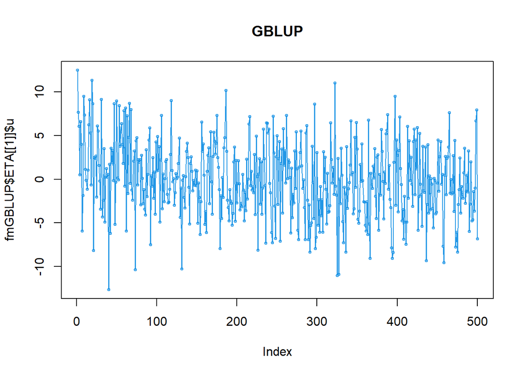

```r
# Estimated breeding values (Genotype effect)
plot(fmGBLUP$ETA[[1]]$u, col=4, cex=.5, type='o', main='GBLUP')
```

## rrBLUP

**Statistical model**

Random regression BLUP or RRBLUP is a marker model that is given as follows:

$$y = 1u + Zm + e$$

where $y$ is the vector of BLUEs data for the target trait; $u$ represents the mean (fixed); $m$ is the vector of random marker effects (assumed to be random), where $m \sim N(0,I\sigma^2_m)$ and $\sigma^2_m$ represents the marker genetic variance; and $e$ is the vector of residuals (random), where $e \sim N(0,I\sigma^2_{res})$, $\sigma^2_{res}$ is the residual variance. The letter $Z$ refers to the incidence matrix for $m$.

Now we can deploy RRBLUP model.

```r
###----------- Linear predictor
ETA = list(A = list(X = Genotypes,   # change from K (relationship matrix) to X (Markers) in ETA
                    model = 'BRR'))  # Specify the model

###----------- Phenotypic data
Y = as.matrix(phenodata[,3])

###----------- Model for trait 1
fmrrBLUP = BGLR(y=Y,             # Phenotypic data
               ETA=ETA,          # Model ETA
               nIter=1200,       # Number of iterations for the model
               burnIn=120,       # Burnin iterations
               thin=5,           # Sampling throughout iterations
               verbose = FALSE)
```

```r
# Mean estimated
fmrrBLUP$mu
```

```
## [1] 149.1196
```

```r
#Variance component for SNP effect
fmrrBLUP$ETA[[1]]$varB
```

```
## [1] 0.02493585
```

```r
#Variance component for the residual effect
fmrrBLUP$varE
```

```
## [1] 43.91798
```

```r
# SNP effects
length(fmrrBLUP$ETA[[1]]$b) #'b' slot
```

```
## [1] 3000
```

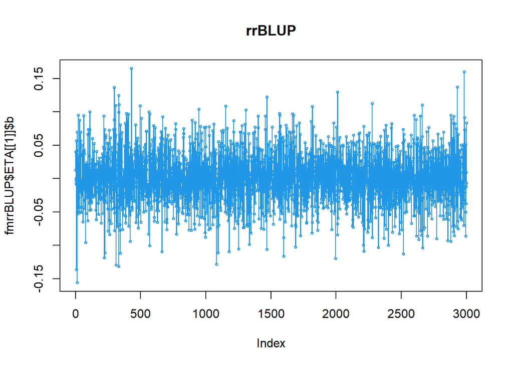

```r
# Estimated effect values (SNP effect)

plot(fmrrBLUP$ETA[[1]]$b, col=4, cex=.5, type='o', main='rrBLUP')
```

**Equivalence rrBLUP/GBLUP:**

We estimated in the above model the additive marker effects. From that, we can backsolve to estimate a Genomic Estimated Breeding Values (GEBV) for each genotype. The simplest way is to use the product between SNPs matrix and the vector of the additive markers’ effects:

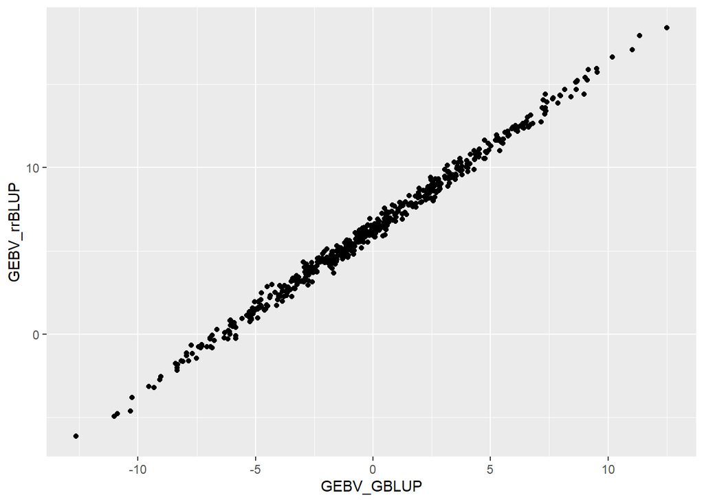

```r
# Backsolve to GEBV values
GEBV = Genotypes %*% fmrrBLUP$ETA[[1]]$b

# Data frame
GBLUP_rrBLUP = data.frame("Genotype" = phenodata$Genotype,
                          "GEBV_GBLUP" = fmGBLUP$ETA[[1]]$u,
                          "GEBV_rrBLUP" = GEBV)

# Estimated effect values (SNP effect)
ggplot(GBLUP_rrBLUP, aes(x = GEBV_GBLUP, y = GEBV_rrBLUP))+
  geom_point()
```

## BayesA

```r
###----------- Phenotypic data
Y = as.matrix(phenodata[,3])

###-----------  Model for trait 1
fmBA <- BGLR(y=Y,            # Phenotypic data
             ETA=list(list(X=Genotypes, model='BayesA')),          # Model ETA
             nIter=1200,       # Number of iterations for the model
             burnIn=120,       # Burnin iterations
             thin=5,
             verbose = FALSE)           # Sampling throughout iterations
```

```r
# Mean estimated
fmBA$mu

# Variance component for the residual effect
fmBA$varE

# SNP effects
length(fmBA$ETA[[1]]$b) #'b' slot
```

[output not shown]

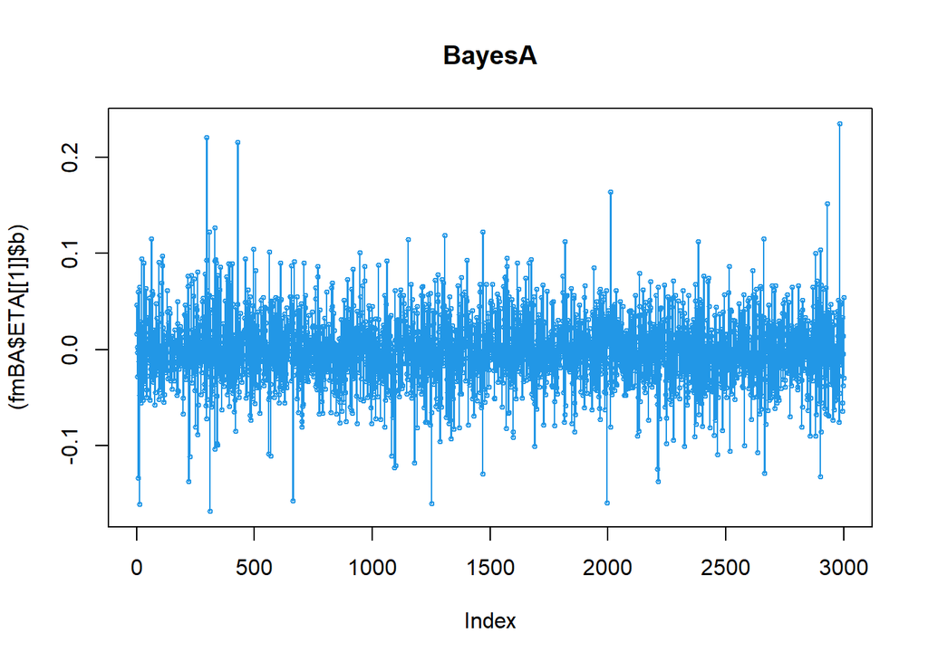

```r
plot((fmBA$ETA[[1]]$b),col=4, cex=.5, type='o', main='BayesA')
```

## BayesB

```r
###----------- Phenotypic data
Y = as.matrix(phenodata[,3])

###-----------  Model for trait 1
fmBB<-BGLR(y=Y,            # Phenotypic data
         ETA=list(A = list(X = Genotypes, model = 'BayesB')),          # Model ETA
         nIter=1200,       # Number of iterations for the model
         burnIn=120,       # Burnin iterations
         thin=5,           # Sampling throughout iterations
         verbose = FALSE)
```

```r
# Mean estimated
fmBB$mu
```

```
## [1] 155.5443
```

```r
#Residual covariance matrix
fmBB$varE
```

```
## [1] 40.49782
```

```r
#Estimated SNP effects
head(fmBB$ETA[[1]]$b)
```

```
##         X1_2         X1_7        X1_16        X1_19        X1_27        X1_34
##  0.062760956  0.052840926 -0.008042352  0.001796811  0.005559859  0.015022433
```

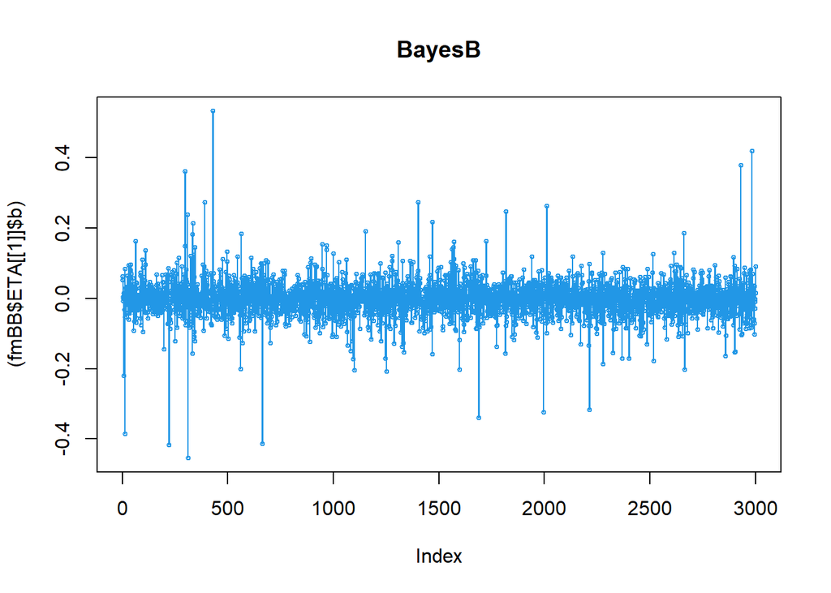

```r
plot((fmBB$ETA[[1]]$b), col=4, cex=.5, type='o', main='BayesB')
```

## RRBLUP vs. BayesB

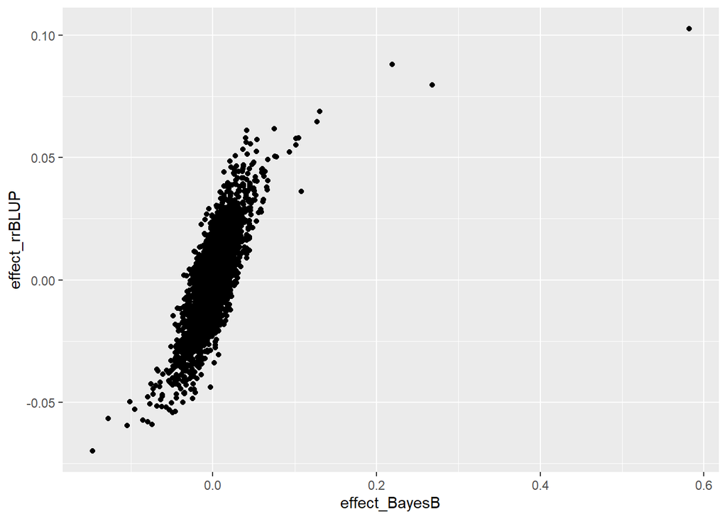

```r
# Filtering for one environment and one trait
phenodat0 = Phenotypes[Phenotypes$Env == 1, c(1,2,6)]

###----------- Phenotypic data
Y = as.matrix(phenodat0[,3])

###-----------  Model for trait 1
fmBB <- BGLR(y=Y,            # Phenotypic data
             ETA=list(list(X=Genotypes, model='BayesB')),          # Model ETA
             nIter=1200,       # Number of iterations for the model
             burnIn=120,       # Burnin iterations
             thin=5,
             verbose = FALSE)           # Sampling throughout iterations


###-----------  Model for trait 1
fmBRR <- BGLR(y=Y,            # Phenotypic data
             ETA=list(list(X=Genotypes, model='BRR')),          # Model ETA
             nIter=1200,       # Number of iterations for the model
             burnIn=120,       # Burnin iterations
             thin=5,
             verbose = FALSE)           # Sampling throughout iterations


# Plotting the effects
BayesB_rrBLUP = data.frame("effect_BayesB" = fmBB$ETA[[1]]$b,
                           "effect_rrBLUP" = fmBRR$ETA[[1]]$b)

ggplot(BayesB_rrBLUP, aes(x = effect_BayesB, y = effect_rrBLUP))+
  geom_point()
```

## Cross-validation

**Using the information to predict accuracy in a CV1 method**

The cross-validations methods are divided into four different classes (sensu Jarquin et al. (2018)), regarding the genotypes and environments. As follows:

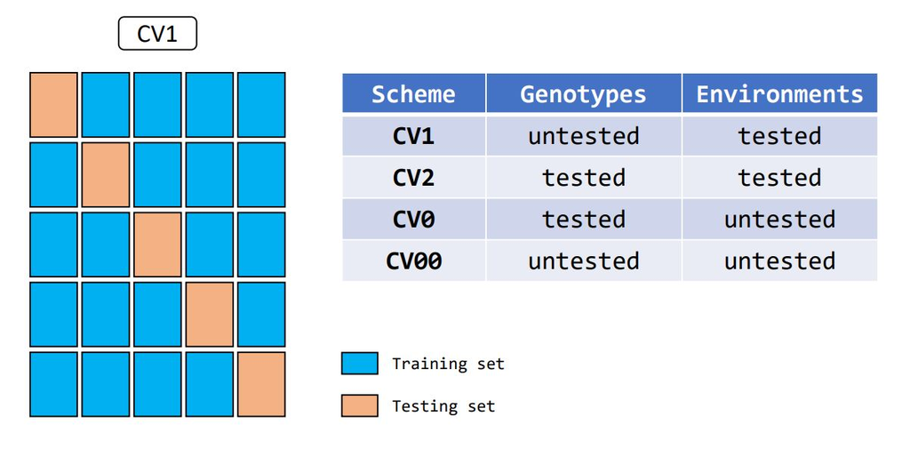

**Figure 1 - Cross-validations schemes.**

**Phenotypic information**

The first step will be to organize the phenotypic information and create the partitions to the cross validation scheme (CV1). Generally, we can divide the phenotypic dataset into two:

Testing set: Population where the phenotype will be predicted based on the markers and in the information from the training set.

Training set: Population with the information that we use to calibrate the model.

```r
###----------- Parameters for the folds
nReps = 5
nFolds = 5

###----------- Output for the estimated values
yHatCV=rep(NA,length(phenodata$Trait1))
pred = data.frame()

###----------- Model
# Phenodata
y = as.matrix(phenodata$Trait1)

# Time for the loop
set.seed(0928761)
 for(Rep in 1:nReps){

 folds=sample(1:nFolds,size=length(phenodata$Trait1),replace=T)

  for(i in 1:max(folds)){
    tst=which(folds==i)
    yNA=y
    yNA[tst]=NA
    # model
    fm=BGLR(y=yNA,
            ETA=list(list(K=GMat,model='RKHS')),
            nIter=1200,
            burnIn=120,
            verbose = FALSE)
    # Predicted values
    yHatCV[tst]=fm$yHat[tst]
  }
 # Accuracy for each fold
 pred=rbind(pred,
            data.frame(Repetitions = Rep,
                       Cor=cor(yHatCV, y)))
}


## Mean for the correlation
mean(pred$Cor)
```

```
## [1] 0.3670201
```

## References

Gaynor, R. C., Gorjanc, G., & Hickey, J. M. (2021). AlphaSimR: An r package for breeding program simulations. *G3*, *11*(2), jkaa017.

Jarquin, D., Howard, R., Xavier, A., & Das Choudhury, S. (2018). Increasing predictive ability by modeling interactions between environments, genotype and canopy coverage image data for soybeans. *Agronomy*, *8*(4), 51.

Pérez, P., & Los Campos, G. de. (2014). Genome-wide regression and prediction with the BGLR statistical package. *Genetics*, *198*(2), 483–495.

Pérez-Rodrı́guez, P., & Los Campos, G. de. (2022). Multitrait bayesian shrinkage and variable selection models with the BGLR-r package. *Genetics*, *222*(1), iyac112.

VanRaden, P. M. (2008). Efficient methods to compute genomic predictions. *Journal of Dairy Science*, *91*(11), 4414–4423.

[^1]: University of Florida, mresende@ufl.edu
[^2]: University of Florida, jhernandezjarqui@ufl.edu
[^3]: University of Florida, deamorimpeixotom@ufl.edu